# Clickstrem in a Self-regulated Learning Environment: A Data Collection Tool

Enzo Novi Migliano

Saint Thomas University, Carnival Cruise Lines School of Science  
* Corresponding author at emigliano@stu.edu

Dr. Sean Mondesire, Supervisor

Saint Thomas University

CIS 627 - Big Data Analytics Capstone - FL2 Term October 19, 2021

Abstract

The present study assesses the feasibility of an application that collects users’ behavioral data in a Shiny App application. The tool is meant for educational settings. The goal is to equip professors with valuable data that allows them to understand the needs and wants of students. The application developed in the present study integrates a database and a programming application interface in order to store and retrieve the data. Also, the application collects several data regarding the student interaction with graphs and their respective timestamp. Finally, the present study suggests possible analyses a professor may perform with the student’s behavioral data.

*Index Terms* - Active learning, self-regulated learning, student engagement, clickstrem data, shiny app, feasibility study.

# I. INTRODUCTION

Only 28% of science, technology, engineer, and mathematics (STEM) students are female [1]. Despite many efforts to address the gender gap, it has yet to be solved. The solution may be improving overall students’ learning experience with new technologies, especially in K-12 education. From paper and pencil to word processing applications, new technologies have influenced the way people learn. R, a popular statistical programming language in academia, has introduced many resources to improve learning, such as Shiny Apps. The solution allows users to develop interactive web pages utilizing R as source code [2]. Nine years after its initial release, Shiny Apps has 48 official extension packages [3]. Various academic activities use the application (e.g., virtual research labs) [4]. In the business domain, web pages often collect users’ behavior data (e.g., cookies). The semi-structured data called click-stream provides insights on how to improve the users’ experience. Yet, Shiny Apps does not inherently collect data from its users. The collection of students’ behaviors within Shiny Apps will equip professors with feedback to improve the classrooms’ learning environment in an ever-increasing technological world. Therefore, in the proposed study, we aim to address the following research question: How to construct a Shiny App that collects user’s behavioral data? The current study will create the tools for data collection through researching available packages and developing necessary source code. The goal is to improve students’ learning environment leading to equal opportunity for both genders in the STEM field.

### Figure 1

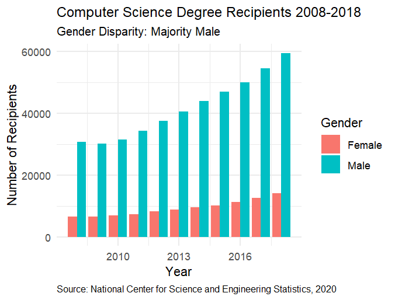

### Figure 2

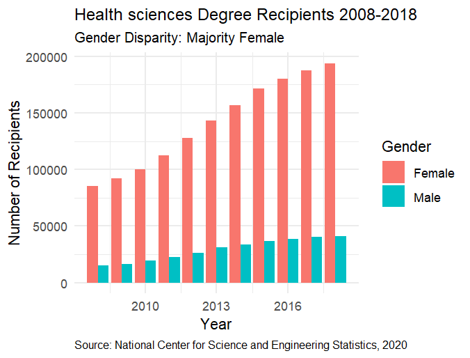

# II. BACKGROUND

The learning outcome of students is the purpose of academic education. From understanding the concept of learning itself [5] to developing methods to further learning outcomes [6] [7], researchers have extensively explored the learning process. Hence, learning is classified in several distinct ways (e.g., passive learning and active learning). *Active learning* (AL) is the commitment of students in learning through tasks that involve active participation and engagement within a group interaction (e.g., group discussion), while *passive learning* is the monological transmission of information [7] [8] [9]. AL demonstrated a significant positive impact on the learning outcome of students. For example, the verbal argumentation students demonstrated deep understanding of course materials which is not possible through passive learning [10]. On another study, an interactive escape room evaluated students in a biology undergraduate class [11]. The students learned from actively solving problems and exchanging ideas with group members which would not be possible in a traditional exam [11]. Although there are several variables associated with AL [8], the engagement of the student is one of its most recurring variables in research. Some researchers even use engagement and AL interchangeably [8]. Therefore, the objective of the current research is to collect AL to students behavioral data with the intention of furthering their learning outcome.  
*Student engagement* is the measure of how well students learn new information according to their behaviors, affects, and cognitive processes [12]. Student engagement is a broad and complex construct [13]. Thus, engagement should be analyzed through different scopes [13]. Skinner and Pitzer developed a nested model of student engagement with four levels from a broad to specific perspective: Engagement with prosocial institutions, engagement with school, engagement in the classroom, and engagement with learning activities [13]. Although engagement at all levels is important, engagement at the learning activities directly interacts with academic learning [13]. Consequently, learning activities englobe a major part of the student learning experience [13]. Engagement is further analyzed into facilitators and indicators [13] [14]. An indicator is the qualitative or quantifiable measure of engagement, whereas a facilitator is a reason or cause of the engagement [13] [14]. Emotions (e.g., satisfaction), cognitive processes (e.g., thoughts), and behaviors (e.g., focus) are used as facilitators and indicators of student engagement [12] [13] [14]. In the current study, new technologies will facilitate and indicate the student behavioral engagement at the learning activity level.  
New technologies opened new facilitators and indicators of student engagement. Besides, new technologies allowed new learning modes as remote or distance learning and presented a significant positive impact on student learning [14]. With the ever-increasing data world, research of learning is fomenting new fields of study. Learning analytics integrates new technologies and big data analytics to promote better learning outcomes for students [15]. One solution that learning analytics researchers presented to record indicators of student engagement is clickstream data [16]. For example, record the behavior of students (e.g., time spent reading an article) in learning management systems (e.g., Canvas) through clickstream data for analysis and comparison with the students’ performance (e.g., grade) [16]. Clickstream data allows detailed visualizations of the student behavior, such as learner trajectory networks [17]. In one study, the learning trajectory networks graphed the path of interaction between the students and one interactive learning application [17]. Despite the intrinsic value of the clickstream data, meaningful analysis of such data-type requires sophisticated analysis [15], often not readily available for all professors. Yet, most of the work in learning analytics focuses on developing solutions to collect data from students. The present study, however, will collect data ready for a simpler yet detailed analysis facilitating the professors’ interpretation of the data. Therefore, the proposed application collects the logs of students’ interaction with widgets from an educational shiny app. The goal is to collect every event in the shiny app with its respective time stamp to allow a variety of visualizations, analyses, and prescriptive analytics to educators.

# III. METHODOLOGY

Shiny App was the selected application for the development of the study’s interactive web page. Shiny App is a web application written in R which allows user interactivity [2]. The shiny app is accessible at https://enzo-migliano.shinyapps.io/PilotApp/, and its source code is available on https://github.com/EnzoNMigliano.

## A. Implementation

### Figure 3

[figure not shown]

## B. Libraries

The application utilizes the following Comprehensive R Archive Network libraries:

### 1) tidyverse Version 1.3.1 [21]

This package is utilized in data extraction, loading, and transformation and the creation of ggplots (i.e., special layered graphs available in R).

### 2) shiny Version 1.7.0 [22]

This package is utilized to create interactive web applications. The package provides an integration of the user interface and the back-end of the web application. The package also has built-in input widgets that are used for interactivity.

### 3) shinycssloaders Version 1.0.0 [23]

This package is utilized to animate the loading process of graphs when a user changes the inputs.

### 4) shinyalert Version 2.0.0 [24]

This package is utilized to generate a popup page when the user enters the web applications. On the popup page, the user will fill in some important demographical information.

### 5) plotly Version 4.10.0 [25]

This package is utilized to further the interactivity of the plots. This package allows users to click on data points and filter data in the graph.

### 6) ggwordcloud Version 0.5.0 [26]

This package is utilized to produce a word cloud graph.

### 7) tm Version 0.7-8 [27]

This package is utilized to remove stop words from the English language and prevent them to appearing in the word cloud graph.

### 8) stringr Version 1.4.0 [28]

This package is utilized to tidy the data from tweets.

### 9) jsonlite Version 1.7.2 [29]

This package is utilized to integrate the shiny app into the application programming interface (API) that will store the data.

### 10) rsconnect Version 0.8.24 [30]

This package is utilized to publish the application on the shinyapp.io domain.

## C. Data Management

### 1) Data Sources

The app displays graphs generated with data from the National Center for Science and Engineering Statistics about science, technology, engineering, and mathematics (STEM) degrees awarded from 2008 to 2018 in the United States [31]. The data provides details regarding the gender and the ethnicity of the person to whom the degree was awarded. Therefore, the graphs will have the general theme of the disparity between degrees awarded in the STEM field. The user will be able to interact with the graphs and generate graphs based on parameters that are defined through the user input.

### 2) Data Selection and Collection

The app will capture relevant data through an API. Every time an important event happens on the web application, a link with the information about the event will be sent to a database (see figure 4). The API will record the IP address, the time, and the data in the URL. At the begging of each session, the user will answer a survey with demographical questions. The following information will be collected at the survey: Age, gender, major, minor, and year. Also, while the user fills the survey, a random identification number will be assigned for the session to guarantee anonymity. Thereafter, the application will record the interaction of the user with the graphs. For such, every time a graph is reloaded, all the parameters of the inputs from the graph are sent to the database. The following information will be collected from the graphs: Current tab and inputs with their respective values and graph identification. To guarantee that the information is sent to the database, the URL calls are written into the server-side of the shiny app together with the code that generates the graph. Finally, the web application will capture a Boolean value to whether a user accessed external links at the bottom of the page.All the variables represent the behavior of the user within the application. This information has great intrinsic value as it provides insights on how to enhance the users’ experience. Therefore, the data will provide insights of the user’s behavioral engagement in learning activities. The goal is to optimize the engagement and consequently the learning outcomes of students.

### Figure 4

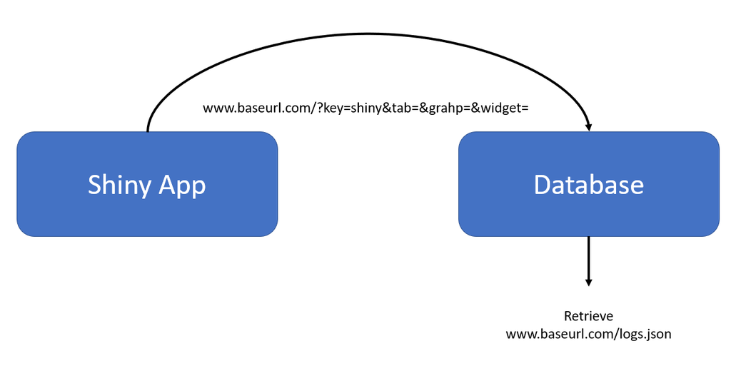

### 3) Data Cleaning and Transformations

The data generated from each student session is retrieved from an API end-point in JSON format. The data will be organized by user id and temporal order to understand the pattern of the user’s behavior. Also, each demographic information collected at the begging of the user’s session will be transformed into a variable represented by a column in a data frame. All data will be transformed into a comma separated value file for further research.

# IV. RESULTS

The current clickstream data focused on the user’s behavior in relation to the interactive graphs available at the app. There was a total of four different interactive graphs available in the application. The results had the following variables:  
- event1: The user has to opt to view one graph at a time. This variable represents which graph the user was visualizing.  
- event 2 & 3: The user had the opportunity to interact with the graph by changing the inputs utilized to form the graph.  
- event 4: Similar to “event2” and “event3”, but this variable has only categorical values.  
-Timestamp: This variable contains the time in which a specific event happened. IP: This variable contains the IP address of the user.

Below are some of the analyses an instructor may find valuable when reviewing the engagement of their students (i.e., application’s user):

### Figure 5

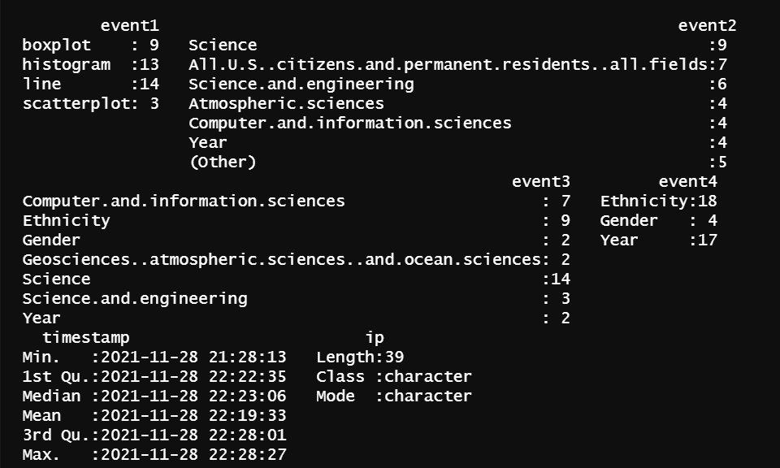

### Figure 6

[figure not shown]

Shapiro-Wilk normality test for event2 W = 0.85423 and p-value = 0.1343. Event2 is normally distributed as p-value is higher than 0.05. Shapiro-Wilk normality test for event3 W = 0.81852 and p-value = 0.06214. Event3 is normally distributed as p-value is higher than 0.05. Welch Two Sample t-test two-tailed event2 and event3 t = 0, df = 7.9541, p-value = 1 ,95 percent confidence interval: -4.383048 4.383048, and sample estimates:mean of x mean of y 5.571429 5.571429. There are no significant differences.

### Figure 7

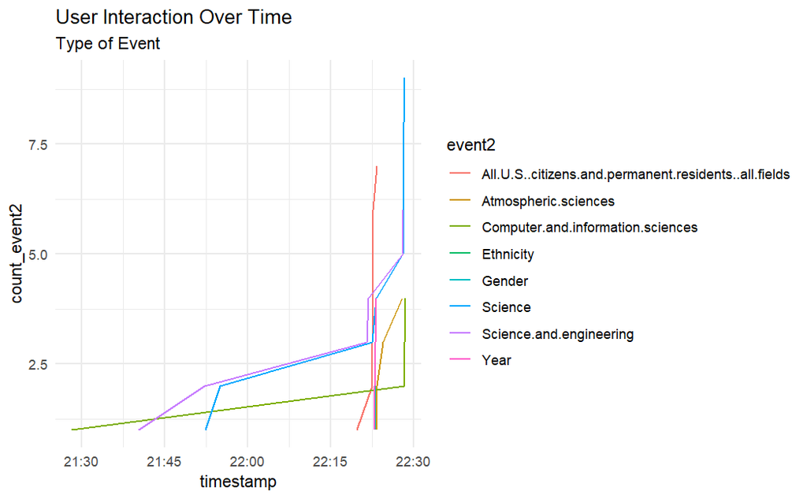

### Figure 8

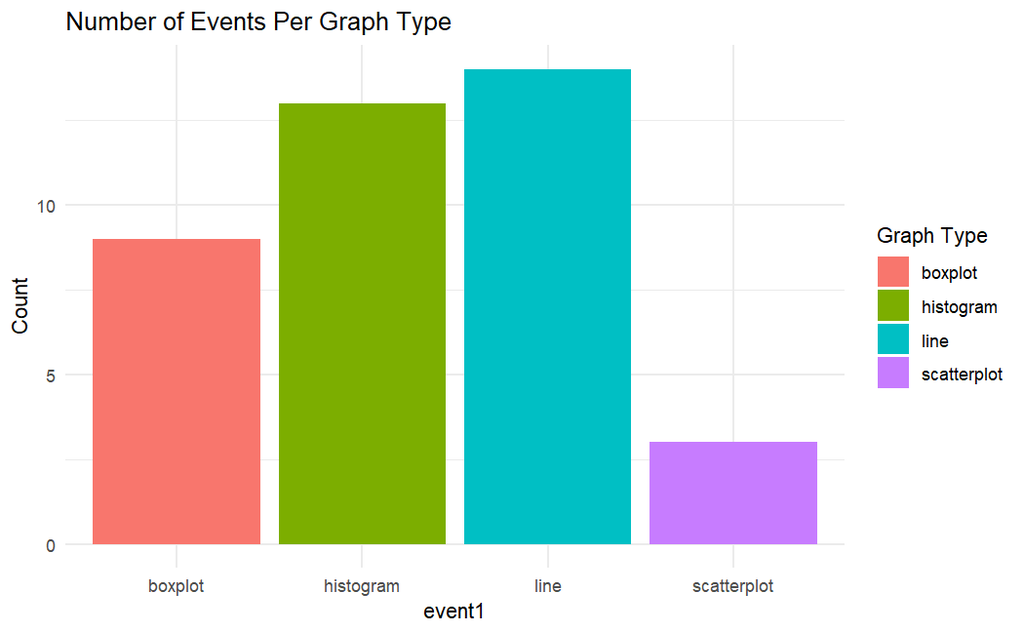

### Figure 9

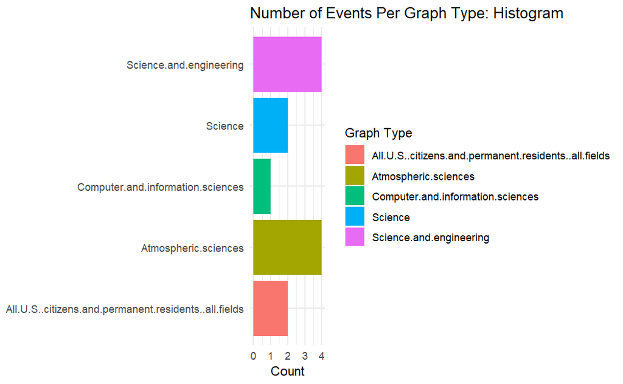

### Figure 10

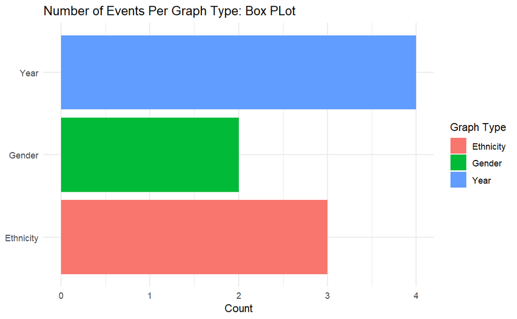

### Figure 11

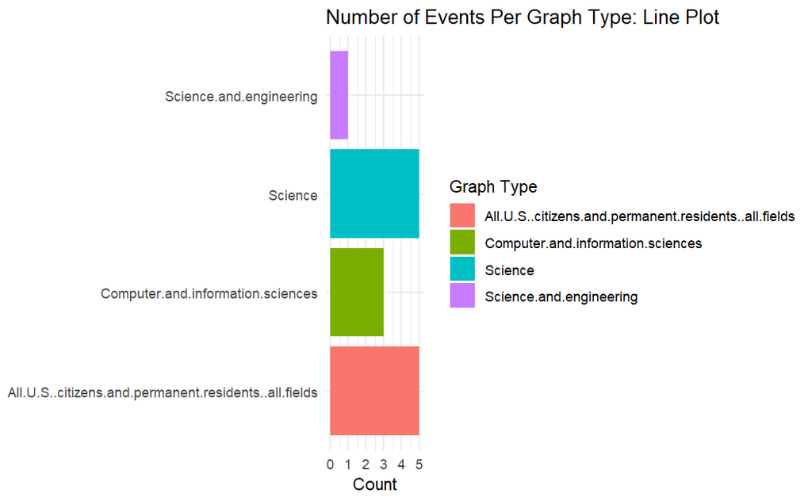

### Figure 12

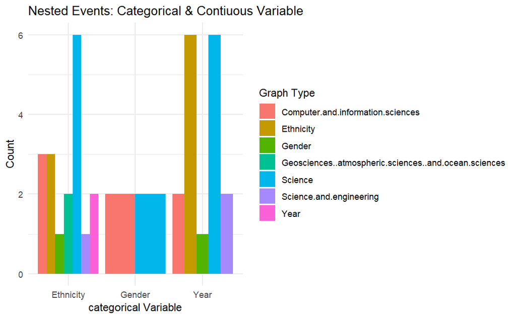

# V. DISCUSSION

Statistical tests to check the normality of the distribution of events in different graphs will help instructors empirically address if events are normally distributed (has a normal distribution of events) or if it is not normally distributed (has a not normal distribution of events). The professor should investigate events that are not normally distributed for reasons why that happened. For example, a professor may ask for feedback from the students regarding problems with a specific graph (see figure 6). A non-normal distribution of events indicates something unusual happened with the user interaction with a certain graph. It is possible that something desirable happened (e.g., the student liked the graph) or something undesirable happened (e.g., the student experienced a problem with the visualization). Therefore, the professor should follow up on any deviance to address the problem.  
The professor may have an overall understanding of the user’s in-app behavior through observing the events across a timeline (see figure 7). For example, if a user have an exponential number of events followed by a plato, the plato phase is likely towards the end of the user interaction. Also, if a user has several peaks of interaction, it may be because the user spends more time understanding the visualization, and it may indicate difficulty in understanding the material. This visualization has numerous possible insights for the professor. However, they all should be followed by a causal investigation of the phenomenon.  
A visualization of the most popular user’s graphs may show the professor which chart is the least enjoyed by the users (See figures 8 through 11). Also, it shows which graph was the “fan-favorite” of the students. On the other hand, the information may also present a form of bug in the graphs. In which case, the graph informs the which graph they should pay attention to and formulate ways to test why there is a difference in the behavior towards each graph.  
The nested events provide insights into how the different inputs interact (see figure 12). The professor may take advantage of the information to understand which are the main interests of their students. There might be a specific intersection of topics that are driving most of the attention of the students. Therefore, the professor may use such information to develop applications that promote more engagement of the students.

# VI. CONCLUSION

The collection of clickstream data in self-regulated learning environment has great potential. Hence, the results of the pilot test of the Shiny App available at https://enzo-migliano.shinyapps.io/Explore_STEM_Majors/ demonstrated the feasibility of accessing behavioral data from users at educational Shiny Apps. The integration of the application with a data base is essential to record the data. Also, an API is necessary to write the data into the data base and read it for later analyses. In the future, as the application is hosted in the shyniapp.io domain and is currently open to the public, it is expected that more users will test the application providing more reliable data regarding its validity. In other words, future work will validate if the data collected from the user’s interaction with the Shiny App application translates into the actual engagement of the student. Also, future work will address the impact of a more engaged student versus a not-so-engaged student in metrics such as grades. Finally, students and instructors will provide feedback on the current state of the application directing other data and information that is vital to understand the engagement of students in self-regulated learning environments.

# References

[1] National Science Board. (2018). *U.S. S&E Workforce: Trends and composition*. https://nsf.gov/statistics/2018/nsb20181/digest/sections/u-s-s-e-workforce-trends-and-composition  
[2] R Studio. (2021). *Shiny*. https://shiny.rstudio.com/  
[3] R Project. (2021). *Available CRAN Packages by Date of Publication*. https://cran.r-project.org/web/packages/available_packages_by_date.html  
[4] R Studio. (2021). *Gallery*. https://shiny.rstudio.com/gallery/  
[5] M. Timms, S. DeVelle, and D. Lay, “Towards a model of how learners process feedback: A deeper look at learning,” *Australian Journal of Education*, vol. 60, no. 2, pp. 128–145, 2016, doi: 10.1177/0004944116652912.  
[6] J. Johnson, J. Spalding, R. Paden, and A. Ziffren, “Recommendations,” in *Those Who Can: Undergraduate Programs to Prepare Arts and Sciences Majors for Teaching*. Washington D.C.: Association of American Colleges, 1989, pp. 68.  
[7] C. C. Bonwell and J. A. Eison, “Active Learning: Creating Excitement in the Classroom,” ASHE-ERIC Higher Education, Washington University, Washington D.C., USA, Rep. No 1, 1991.  
[8] S. Vanhorn, S. M. Ward, K. M. Weismann, H. Crandall, J. Reule, and R. Leonard, “Exploring active learning theories, practices, and contexts,” *Communication Research Trends*, vol. 38, no. 3, pp. 5-25, 2019.  
[9] M. Cartolari, P. Carlino, and L. M. Colombo, “Reading and note taking in monological and dialogical classes in social sciences,” *Australian Journal of Teaching Education*, vol. 38, no. 6, pp. 158-183, 2013.  
[10] P. de Caprariis, C. Barman, and P. Magee, “Monitoring the benefits of active learning exercises in introductory survey courses in dcience: an Attempt to Improve the education of prospective public school teachers,” *Journal of the Scholarship of Teaching and Learning*, vol. 1, no. 2, pp. 13-23, 2001.  
[11] B. Gaia, “Pushing active learning into assessment with a genetics escape-room final: gamification to develop team skills in STEM, on ground and online,” *Journal of Higher Education Theory and Practice*, vol. 21, no. 11, page 73-85, 2021.  
[12] A. L. Reschly and S. L. Christenson, “Jingle, jangle, and conceptual haziness: Evolution and future directions of the engagement construct,” in *Handbook of Student Engagement*. New York, Springer, 2012, pp. 1.  
[13] E. A. Skinner and J. R. Pitzer, “Developmental dynamics of student engagement, coping, and everyday resilience,” in *Handbook of Student Engagement*. New York, Springer, 2012, pp. 1.  
[14] C. Henrie, L. Halverson, and C. Graham, “Measuring Student Engagement in Technology-Mediated Learning: A Review,” *Computers & Education*, vol. 90, no. 26, pp. 36-53, 2015, doi: 10.1016/j.compedu.2015.09.005  
[15] I. Abakumova, I. Bakaeva, A. Grishina, and E. Dyakova, “Active Learning Technologies in Distance Education of Gifted Students,” International Journal of Cognitive Research in Science, *Engineering and Education*, vol. 7, no. 1, pp. 85-94, 2019.  
[16] E. Atasoy, H. Bozna, A. S€onmez, A. A. Akkurt, G. T. Buy€ukk€€ose, and M. Fırat, “Active learning analytics in mobile: visions from PhD students,” *Asian Association of Open Universities Journal*, vol. 15, no. 2, pp. 145-166, 2020, doi: 10.1108/AAOUJ-11-2019-0055  
[17] R. Baker, D. Xu, J. Park, R. Yu, Q. Li, B. Cung, C. Fischer, F. Rodriguez, M. Warschauer, and P. Smyth, “The benefits and caveats of using clickstream data to understand student self-regulatory behaviors: opening the black box of learning processes,” *International Journal of Educational Technology in Higher Education*, vol. 17, no. 13, 2020, doi: 10.1186/s41239-020-00187-1  
[18 ]M. Ginda, M. C. Richey, M. Cousino, and K. Bo¨rner, “Visualizing learner engagement, performance, and trajectories to evaluate and optimize online course design,” *PLoS ONE*, vol. 14, no. 5,2019, doi: 10.1371/journal. pone.0215964  
[21] H. Wickham , M. Averick , J. Bryan , W. Chang , L. D. McGowan , R. François , G. Grolemund , A. Hayes , L. Henry , J. Hester , M. Kuhn , T. L. Pedersen , E. Miller , S. M. Bache , K. Müller , J. Ooms , D. Robinson , D. P. Seidel , V. Spinu , K. Takahashi , D. Vaughan , C. Wilke, K. Woo, and H. Yutani, “Welcome to the tidyverse”, *Journal of Open Source Software*, vol.4, no.43, pp. 1686, 2019.  
[22] W. Chang, J. Cheng, J. Allaire, C. Sievert, B. Schloerke, Y. Xie, J. Allen, J. McPherson, A. Dipert, and B. Borges,”shiny: Web Application Framework for R”, *R package version 1.7.0*, 2021. https://CRAN.R-project.org/package=shiny  
[23] A. Sali and D. Attali, “shinycssloaders: Add loading animations to a ‘shiny’ output while It’s recalculating”, *R package version 1.0.0*, 2020. https://CRAN.R-project.org/package=shinycssloaders  
[24] D. Attali and T. Edwards, “shinyalert: easily create pretty popup messages (modals) in ‘Shiny’”, *R package version 2.0.0*, 2020. https://CRAN.R-project.org/package=shinyalert  
[25] C. Sievert,“Interactive web-based data visualization with R, plotly, and shiny”, *Chapman and Hall*, 2020.  
[26] E.L. Pennec and K. Slowikowski, “ggwordcloud: A word cloud geom for ‘ggplot2’”, *R package version 0.5.0*, 2019. https://CRAN.R-project.org/package=ggwordcloud  
[27] I. Feinerer and K. Hornik, “tm: Text mining package”, *R package version 0.7-8*, 2020.  
[28] H. Wickham, “stringr: Simple, consistent wrappers for common string operations”, *R package version 1.4.0*, 2019. https://CRAN.R-project.org/package=stringr  
[29] J. Ooms, “The jsonlite package: A practical and consistent mapping between JSON data and R objects.” *arXiv:1403.2805 [stat.CO]*, 2014.  
[30] J. McPherson and J. J. Allaire, “rsconnect: deployment interface for R markdown documents and shiny applications”, *R package version 0.8.24*, 2021. https://CRAN.R-project.org/package=rsconnect  
[31] National Science Foundation, “Science and engineering degrees, by race and ethnicity of recipients: 2008–18”, 2020, https://www.nsf.gov/statistics/degreerecipients/